# INN Hotels Project

## Context

A significant number of hotel bookings are called-off due to cancellations or no-shows. The typical reasons for cancellations include change of plans, scheduling conflicts, etc. This is often made easier by the option to do so free of charge or preferably at a low cost which is beneficial to hotel guests but it is a less desirable and possibly revenue-diminishing factor for hotels to deal with. Such losses are particularly high on last-minute cancellations.

The new technologies involving online booking channels have dramatically changed customers’ booking possibilities and behavior. This adds a further dimension to the challenge of how hotels handle cancellations, which are no longer limited to traditional booking and guest characteristics.

The cancellation of bookings impact a hotel on various fronts:

- Loss of resources (revenue) when the hotel cannot resell the room.
- Additional costs of distribution channels by increasing commissions or paying for publicity to help sell these rooms.
- Lowering prices last minute, so the hotel can resell a room, resulting in reducing the profit margin.
- Human resources to make arrangements for the guests.

## Objective

The increasing number of cancellations calls for a Machine Learning based solution that can help in predicting which booking is likely to be canceled. INN Hotels Group has a chain of hotels in Portugal, they are facing problems with the high number of booking cancellations and have reached out to your firm for data-driven solutions. You as a data scientist have to analyze the data provided to find which factors have a high influence on booking cancellations, build a predictive model that can predict which booking is going to be canceled in advance, and help in formulating profitable policies for cancellations and refunds.

## Data Description

The data contains the different attributes of customers' booking details. The detailed data dictionary is given below.

**Data Dictionary**

- Booking_ID: unique identifier of each booking
- no_of_adults: Number of adults
- no_of_children: Number of Children
- no_of_weekend_nights: Number of weekend nights (Saturday or Sunday) the guest stayed or booked to stay at the hotel
- no_of_week_nights: Number of week nights (Monday to Friday) the guest stayed or booked to stay at the hotel
- type_of_meal_plan: Type of meal plan booked by the customer:
  - Not Selected – No meal plan selected
  - Meal Plan 1 – Breakfast
  - Meal Plan 2 – Half board (breakfast and one other meal)
  - Meal Plan 3 – Full board (breakfast, lunch, and dinner)
- required_car_parking_space: Does the customer require a car parking space? (0 - No, 1- Yes)
- room_type_reserved: Type of room reserved by the customer. The values are ciphered (encoded) by INN Hotels.
- lead_time: Number of days between the date of booking and the arrival date
- arrival_year: Year of arrival date
- arrival_month: Month of arrival date
- arrival_date: Date of the month
- market_segment_type: Market segment designation.
- repeated_guest: Is the customer a repeated guest? (0 - No, 1- Yes)
- no_of_previous_cancellations: Number of previous bookings that were canceled by the customer prior to the current booking
- no_of_previous_bookings_not_canceled: Number of previous bookings not canceled by the customer prior to the current booking
- avg_price_per_room: Average price per day of the reservation; prices of the rooms are dynamic. (in euros)
- no_of_special_requests: Total number of special requests made by the customer (e.g. high floor, view from the room, etc)
- booking_status: Flag indicating if the booking was canceled or not.

## Importing necessary libraries and data

```python
# To filter the warnings
import warnings

warnings.filterwarnings("ignore")
from statsmodels.tools.sm_exceptions import ConvergenceWarning

warnings.simplefilter("ignore", ConvergenceWarning)

# to help with reading and manipulating data
import pandas as pd
import numpy as np

# for visualizing data
import matplotlib.pyplot as plt
import seaborn as sns

# For randomized data splitting
from sklearn.model_selection import train_test_split

# To build linear model for statistical analysis and prediction
import statsmodels.stats.api as sms
from statsmodels.stats.outliers_influence import variance_inflation_factor
import statsmodels.api as sm
from statsmodels.tools.tools import add_constant
from sklearn.linear_model import LogisticRegression

# Removes the limit for the number of displayed columns
pd.set_option("display.max_columns", None)
# Sets the limit for the number of displayed rows
pd.set_option("display.max_rows", 200)

# To get diferent metric scores
from sklearn import metrics
from sklearn.metrics import accuracy_score, roc_curve, confusion_matrix, roc_auc_score, f1_score, recall_score, precision_score, plot_confusion_matrix, precision_recall_curve, make_scorer
```

```python
# import the dataset
from google.colab import files
import io

try:
  uploaded
except NameError:
  uploaded = files.upload()

data = pd.read_csv(io.BytesIO(uploaded["INNHotelsGroup.csv"]))
```

Upload widget is only available when the cell has been executed in the current browser session. Please rerun this cell to enable.

```
Saving INNHotelsGroup.csv to INNHotelsGroup.csv
```

```python
# make a copy of the dataset in case it's needed for the decision tree
datacopy = data.copy()
```

## Data Overview

- Observations
- Sanity checks

```python
# view first 5 rows
data.head()
```

|  | Booking_ID | no_of_adults | no_of_children | no_of_weekend_nights | no_of_week_nights | type_of_meal_plan | required_car_parking_space | room_type_reserved | lead_time | arrival_year | arrival_month | arrival_date | market_segment_type | repeated_guest | no_of_previous_cancellations | no_of_previous_bookings_not_canceled | avg_price_per_room | no_of_special_requests | booking_status |
| --- | --- | --- | --- | --- | --- | --- | --- | --- | --- | --- | --- | --- | --- | --- | --- | --- | --- | --- | --- |
| 0 | INN00001 | 2 | 0 | 1 | 2 | Meal Plan 1 | 0 | Room_Type 1 | 224 | 2017 | 10 | 2 | Offline | 0 | 0 | 0 | 65.00 | 0 | Not_Canceled |
| 1 | INN00002 | 2 | 0 | 2 | 3 | Not Selected | 0 | Room_Type 1 | 5 | 2018 | 11 | 6 | Online | 0 | 0 | 0 | 106.68 | 1 | Not_Canceled |
| 2 | INN00003 | 1 | 0 | 2 | 1 | Meal Plan 1 | 0 | Room_Type 1 | 1 | 2018 | 2 | 28 | Online | 0 | 0 | 0 | 60.00 | 0 | Canceled |
| 3 | INN00004 | 2 | 0 | 0 | 2 | Meal Plan 1 | 0 | Room_Type 1 | 211 | 2018 | 5 | 20 | Online | 0 | 0 | 0 | 100.00 | 0 | Canceled |
| 4 | INN00005 | 2 | 0 | 1 | 1 | Not Selected | 0 | Room_Type 1 | 48 | 2018 | 4 | 11 | Online | 0 | 0 | 0 | 94.50 | 0 | Canceled |

```python
# view last 5 rows
data.tail()
```

|  | Booking_ID | no_of_adults | no_of_children | no_of_weekend_nights | no_of_week_nights | type_of_meal_plan | required_car_parking_space | room_type_reserved | lead_time | arrival_year | arrival_month | arrival_date | market_segment_type | repeated_guest | no_of_previous_cancellations | no_of_previous_bookings_not_canceled | avg_price_per_room | no_of_special_requests | booking_status |
| --- | --- | --- | --- | --- | --- | --- | --- | --- | --- | --- | --- | --- | --- | --- | --- | --- | --- | --- | --- |
| 36270 | INN36271 | 3 | 0 | 2 | 6 | Meal Plan 1 | 0 | Room_Type 4 | 85 | 2018 | 8 | 3 | Online | 0 | 0 | 0 | 167.80 | 1 | Not_Canceled |
| 36271 | INN36272 | 2 | 0 | 1 | 3 | Meal Plan 1 | 0 | Room_Type 1 | 228 | 2018 | 10 | 17 | Online | 0 | 0 | 0 | 90.95 | 2 | Canceled |
| 36272 | INN36273 | 2 | 0 | 2 | 6 | Meal Plan 1 | 0 | Room_Type 1 | 148 | 2018 | 7 | 1 | Online | 0 | 0 | 0 | 98.39 | 2 | Not_Canceled |
| 36273 | INN36274 | 2 | 0 | 0 | 3 | Not Selected | 0 | Room_Type 1 | 63 | 2018 | 4 | 21 | Online | 0 | 0 | 0 | 94.50 | 0 | Canceled |
| 36274 | INN36275 | 2 | 0 | 1 | 2 | Meal Plan 1 | 0 | Room_Type 1 | 207 | 2018 | 12 | 30 | Offline | 0 | 0 | 0 | 161.67 | 0 | Not_Canceled |

```python
# understand the data shape
data.shape
```

```
(36275, 19)
```

Observation: There are 36,275 rows and 19 columns

```python
data.info()
```

```
<class 'pandas.core.frame.DataFrame'>
RangeIndex: 36275 entries, 0 to 36274
Data columns (total 19 columns):
 #   Column                                Non-Null Count  Dtype
---  ------                                --------------  -----
 0   Booking_ID                            36275 non-null  object
 1   no_of_adults                          36275 non-null  int64
 2   no_of_children                        36275 non-null  int64
 3   no_of_weekend_nights                  36275 non-null  int64
 4   no_of_week_nights                     36275 non-null  int64
 5   type_of_meal_plan                     36275 non-null  object
 6   required_car_parking_space            36275 non-null  int64
 7   room_type_reserved                    36275 non-null  object
 8   lead_time                             36275 non-null  int64
 9   arrival_year                          36275 non-null  int64
 10  arrival_month                         36275 non-null  int64
 11  arrival_date                          36275 non-null  int64
 12  market_segment_type                   36275 non-null  object
 13  repeated_guest                        36275 non-null  int64
 14  no_of_previous_cancellations          36275 non-null  int64
 15  no_of_previous_bookings_not_canceled  36275 non-null  int64
 16  avg_price_per_room                    36275 non-null  float64
 17  no_of_special_requests                36275 non-null  int64
 18  booking_status                        36275 non-null  object
dtypes: float64(1), int64(13), object(5)
memory usage: 5.3+ MB
```

```python
# check for nulls
data.isnull().values.any()
```

```
False
```

Observation: There are no obvious nulls in the dataset, but there may be other values missing that we need to account for.

```python
# print the statistical summary for each variable
data.describe(include='all').T
```

|  | count | unique | top | freq | mean | std | min | 25% | 50% | 75% | max |
| --- | --- | --- | --- | --- | --- | --- | --- | --- | --- | --- | --- |
| Booking_ID | 36275 | 36275 | INN00001 | 1 | NaN | NaN | NaN | NaN | NaN | NaN | NaN |
| no_of_adults | 36275.0 | NaN | NaN | NaN | 1.844962 | 0.518715 | 0.0 | 2.0 | 2.0 | 2.0 | 4.0 |
| no_of_children | 36275.0 | NaN | NaN | NaN | 0.105279 | 0.402648 | 0.0 | 0.0 | 0.0 | 0.0 | 10.0 |
| no_of_weekend_nights | 36275.0 | NaN | NaN | NaN | 0.810724 | 0.870644 | 0.0 | 0.0 | 1.0 | 2.0 | 7.0 |
| no_of_week_nights | 36275.0 | NaN | NaN | NaN | 2.2043 | 1.410905 | 0.0 | 1.0 | 2.0 | 3.0 | 17.0 |
| type_of_meal_plan | 36275 | 4 | Meal Plan 1 | 27835 | NaN | NaN | NaN | NaN | NaN | NaN | NaN |
| required_car_parking_space | 36275.0 | NaN | NaN | NaN | 0.030986 | 0.173281 | 0.0 | 0.0 | 0.0 | 0.0 | 1.0 |
| room_type_reserved | 36275 | 7 | Room_Type 1 | 28130 | NaN | NaN | NaN | NaN | NaN | NaN | NaN |
| lead_time | 36275.0 | NaN | NaN | NaN | 85.232557 | 85.930817 | 0.0 | 17.0 | 57.0 | 126.0 | 443.0 |
| arrival_year | 36275.0 | NaN | NaN | NaN | 2017.820427 | 0.383836 | 2017.0 | 2018.0 | 2018.0 | 2018.0 | 2018.0 |
| arrival_month | 36275.0 | NaN | NaN | NaN | 7.423653 | 3.069894 | 1.0 | 5.0 | 8.0 | 10.0 | 12.0 |
| arrival_date | 36275.0 | NaN | NaN | NaN | 15.596995 | 8.740447 | 1.0 | 8.0 | 16.0 | 23.0 | 31.0 |
| market_segment_type | 36275 | 5 | Online | 23214 | NaN | NaN | NaN | NaN | NaN | NaN | NaN |
| repeated_guest | 36275.0 | NaN | NaN | NaN | 0.025637 | 0.158053 | 0.0 | 0.0 | 0.0 | 0.0 | 1.0 |
| no_of_previous_cancellations | 36275.0 | NaN | NaN | NaN | 0.023349 | 0.368331 | 0.0 | 0.0 | 0.0 | 0.0 | 13.0 |
| no_of_previous_bookings_not_canceled | 36275.0 | NaN | NaN | NaN | 0.153411 | 1.754171 | 0.0 | 0.0 | 0.0 | 0.0 | 58.0 |
| avg_price_per_room | 36275.0 | NaN | NaN | NaN | 103.423539 | 35.089424 | 0.0 | 80.3 | 99.45 | 120.0 | 540.0 |
| no_of_special_requests | 36275.0 | NaN | NaN | NaN | 0.619655 | 0.786236 | 0.0 | 0.0 | 0.0 | 1.0 | 5.0 |
| booking_status | 36275 | 2 | Not_Canceled | 24390 | NaN | NaN | NaN | NaN | NaN | NaN | NaN |

Observations:

- The most common meal plan tupe is meal plan 1.
- The most common room type reserved is room type 1.
- The most comon market segment type is online.
- The most common booking status is not canceled.
- The mean avg price per room is $103.

## Exploratory Data Analysis (EDA)

- EDA is an important part of any project involving data.
- It is important to investigate and understand the data better before building a model with it.
- A few questions have been mentioned below which will help you approach the analysis in the right manner and generate insights from the data.
- A thorough analysis of the data, in addition to the questions mentioned below, should be done.

### Univariate & Bivariate Analysis

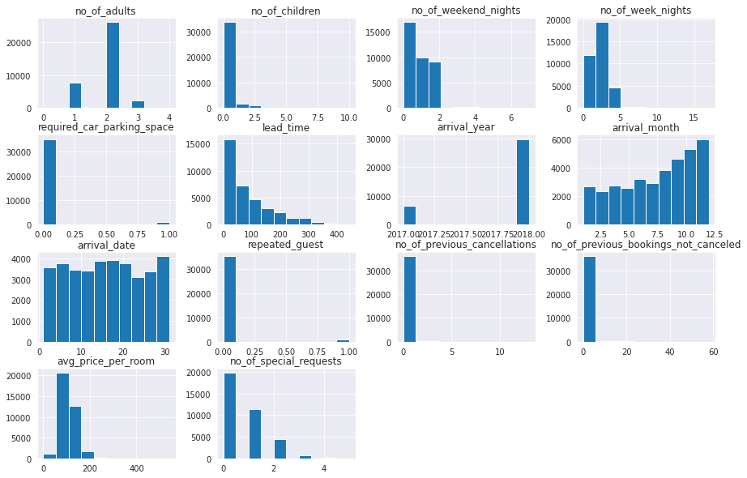

```python
# plot the distributions for numeric variables
sns.set_style("darkgrid")
data.hist(figsize=(15, 10))
plt.show()
```

Observations:

- We see that avg_price_per_room has 0 values, which should not be the case since a room would not be free.
- We will replace 0 values for avg_price_per_room with NaN.

```python
# check the unique values for price per room
data['avg_price_per_room'].unique()
```

```
array([ 65.  , 106.68,  60.  , ..., 118.43, 137.25, 167.8 ])
```

```python
# check the unique values for number of special requests
data['no_of_special_requests'].unique()
```

```
array([0, 1, 3, 2, 4, 5])
```

```python
# defining the column wheere we need to replace 0 with NaN
cols = ["avg_price_per_room"]
```

```python
# replacing 0 with NaN
data[cols] = data[cols].replace(0, np.nan)
```

```python
# let's check missing values in the data again
data.isna().sum()
```

```
Booking_ID                                0
no_of_adults                              0
no_of_children                            0
no_of_weekend_nights                      0
no_of_week_nights                         0
type_of_meal_plan                         0
required_car_parking_space                0
room_type_reserved                        0
lead_time                                 0
arrival_year                              0
arrival_month                             0
arrival_date                              0
market_segment_type                       0
repeated_guest                            0
no_of_previous_cancellations              0
no_of_previous_bookings_not_canceled      0
avg_price_per_room                      545
no_of_special_requests                    0
booking_status                            0
dtype: int64
```

Observation: We now see 545 null values for avg price per room that we need to impute. Let's see if avg price per room has a strong correlation with any other variable to understand the best value to use.

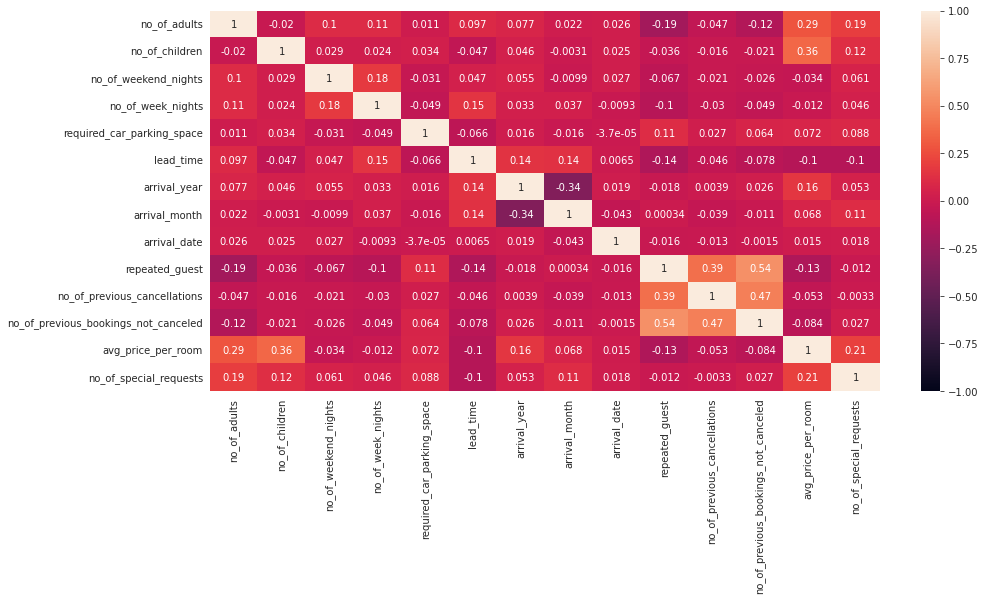

```python
plt.figure(figsize=(15, 7))
sns.heatmap(data.corr(), annot=True, vmin=-1, vmax=1)
plt.show()
```

Observation: avg price per room does not seem to have a strong correlation with any other numeric variables. Let's use median as the standard imputation method.

```python
# Let's impute missing values using the median
data[cols] = data[cols].fillna(data[cols].median())
```

```python
# let's check missing values in the data again
data.isna().sum()
```

```
Booking_ID                              0
no_of_adults                            0
no_of_children                          0
no_of_weekend_nights                    0
no_of_week_nights                       0
type_of_meal_plan                       0
required_car_parking_space              0
room_type_reserved                      0
lead_time                               0
arrival_year                            0
arrival_month                           0
arrival_date                            0
market_segment_type                     0
repeated_guest                          0
no_of_previous_cancellations            0
no_of_previous_bookings_not_canceled    0
avg_price_per_room                      0
no_of_special_requests                  0
booking_status                          0
dtype: int64
```

Observation: All missing values for avg price per room have now been imputed using the median price per room

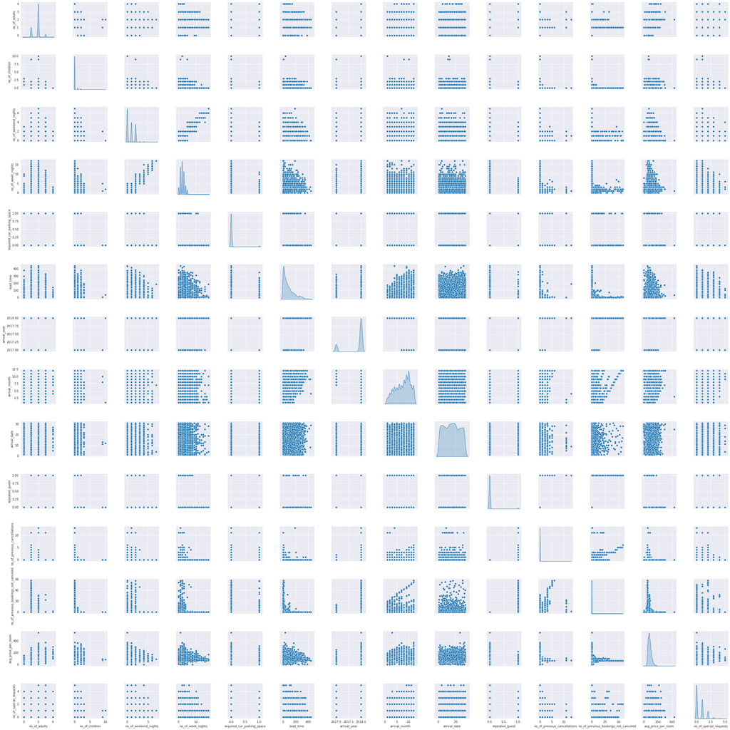

```python
# pairplot to further check for correlation
sns.pairplot(data=data, diag_kind="kde")
plt.show()
```

Observations: We don't have any strong correlations between our numeric variables.

### Explore Categorical Variables

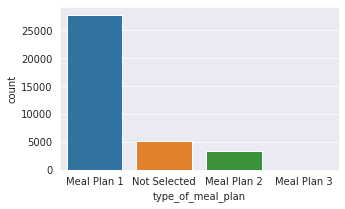

```python
# now let's look at categorical variables
plt.figure(figsize=(5,3))
sns.countplot(data=data, x='type_of_meal_plan')
plt.show()
```

```python
data['type_of_meal_plan'].value_counts()
```

```
Meal Plan 1     27835
Not Selected     5130
Meal Plan 2      3305
Meal Plan 3         5
Name: type_of_meal_plan, dtype: int64
```

```python
data.groupby('type_of_meal_plan')['booking_status'].value_counts(normalize='true')
```

```
type_of_meal_plan  booking_status
Meal Plan 1        Not_Canceled      0.688198
                   Canceled          0.311802
Meal Plan 2        Not_Canceled      0.544327
                   Canceled          0.455673
Meal Plan 3        Not_Canceled      0.800000
                   Canceled          0.200000
Not Selected       Not_Canceled      0.668811
                   Canceled          0.331189
Name: booking_status, dtype: float64
```

Observations: Only 5 bookings selected meal plan 3, the vast majority booked meal plan 1. Bookings with meal plan 2 seem more likely to cancel.

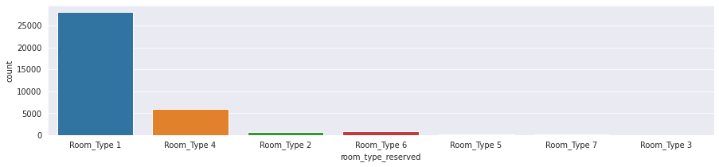

```python
plt.figure(figsize=(15,3))
sns.countplot(data=data, x='room_type_reserved')
plt.show()
```

```python
data['room_type_reserved'].value_counts()
```

```
Room_Type 1    28130
Room_Type 4     6057
Room_Type 6      966
Room_Type 2      692
Room_Type 5      265
Room_Type 7      158
Room_Type 3        7
Name: room_type_reserved, dtype: int64
```

```python
data.groupby('room_type_reserved')['booking_status'].value_counts(normalize='true')
```

```
room_type_reserved  booking_status
Room_Type 1         Not_Canceled      0.677497
                    Canceled          0.322503
Room_Type 2         Not_Canceled      0.670520
                    Canceled          0.329480
Room_Type 3         Not_Canceled      0.714286
                    Canceled          0.285714
Room_Type 4         Not_Canceled      0.658412
                    Canceled          0.341588
Room_Type 5         Not_Canceled      0.728302
                    Canceled          0.271698
Room_Type 6         Not_Canceled      0.579710
                    Canceled          0.420290
Room_Type 7         Not_Canceled      0.772152
                    Canceled          0.227848
Name: booking_status, dtype: float64
```

Observation: Most people chose room type 1 followed by room type 4. Very few booked room type 3. Bookings for room type 6 have the highest likelihood of being cancelled.

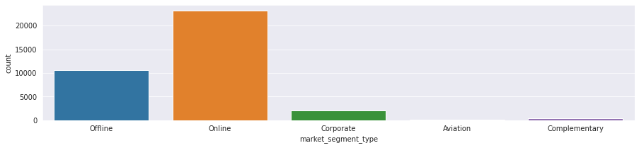

```python
plt.figure(figsize=(15,3))
sns.countplot(data=data, x='market_segment_type')
plt.show()
```

```python
data['market_segment_type'].value_counts()
```

```
Online           23214
Offline          10528
Corporate         2017
Complementary      391
Aviation           125
Name: market_segment_type, dtype: int64
```

```python
data.groupby('market_segment_type')['booking_status'].value_counts(normalize='true')
```

```
market_segment_type  booking_status
Aviation             Not_Canceled      0.704000
                     Canceled          0.296000
Complementary        Not_Canceled      1.000000
Corporate            Not_Canceled      0.890927
                     Canceled          0.109073
Offline              Not_Canceled      0.700513
                     Canceled          0.299487
Online               Not_Canceled      0.634919
                     Canceled          0.365081
Name: booking_status, dtype: float64
```

Observations: Most bookings are made online. There were 391 complementary bookings which I assume are either bookings with loyalty points or some other loyalty/marketing offering. Those bookings were never cancelled. Corporate bookings see the next lowest level of cancellations at around ~11%.

**Leading Questions**:

1. What are the busiest months in the hotel?
2. Which market segment do most of the guests come from?
3. Hotel rates are dynamic and change according to demand and customer demographics. What are the differences in room prices in different market segments?
4. What percentage of bookings are canceled?
5. Repeating guests are the guests who stay in the hotel often and are important to brand equity. What percentage of repeating guests cancel?
6. Many guests have special requirements when booking a hotel room. Do these requirements affect booking cancellation?

### 1. What are the busiest months in the hotel?

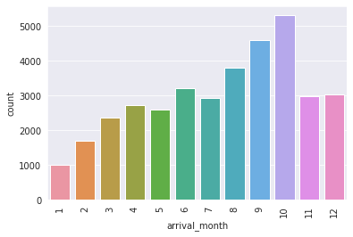

```python
sns.countplot(data=data, x='arrival_month')
plt.xticks(rotation=90);
```

Observation: October seems to be the busiest month, and fall in general (August, September, October) seems to be the busiest season. But let's also make sure that October did not have a high number of cancelations that could be throwing off these results.

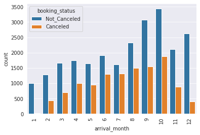

```python
sns.countplot(data=data, x='arrival_month', hue = 'booking_status')
plt.xticks(rotation=90);
```

We see that October also had the highest number of cancelations, however, there were still the most not canceled bookings that month too.

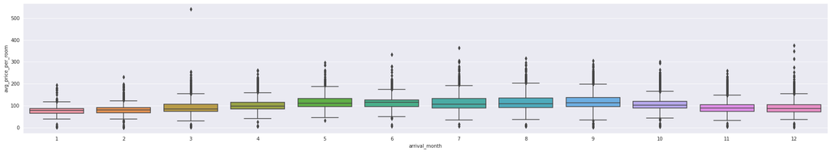

```python
# check the avg room price by month to see if that is the reason October is most popular
plt.figure(figsize=(30,5))
sns.boxplot(data=data,x='arrival_month',y='avg_price_per_room')
plt.show()
```

Observation: October does seem to have lower prices on average than some other months like July & August, but months like January and February offer even lower prices.

### 2. Which market segment do most of the guests come from?

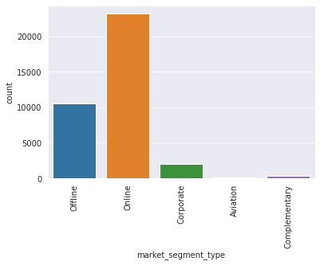

```python
sns.countplot(data=data, x='market_segment_type')
plt.xticks(rotation=90);
```

Observation: The majority of guests come from the online market segment.

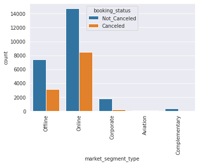

```python
sns.countplot(data=data, x='market_segment_type', hue = 'booking_status')
plt.xticks(rotation=90);
```

Observation: The majority of cancelations also come from the online market segment.

### 3. Hotel rates are dynamic and change according to demand and customer demographics. What are the differences in room prices in different market segments?

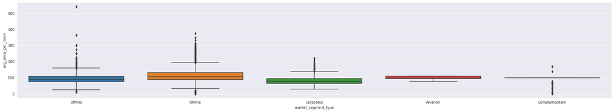

```python
plt.figure(figsize=(30,5))
sns.boxplot(data=data,x='market_segment_type',y='avg_price_per_room')
plt.show()
```

Observation: The average room price for bookings made online tends to be higher than other market segments.

### 4. What percentage of bookings are canceled?

```python
data['booking_status'].value_counts()
```

```
Not_Canceled    24390
Canceled        11885
Name: booking_status, dtype: int64
```

```python
data['booking_status'].value_counts(normalize='true')
```

```
Not_Canceled    0.672364
Canceled        0.327636
Name: booking_status, dtype: float64
```

Observation: ~33% of bookings are canceled.

### 5. Repeating guests are the guests who stay in the hotel often and are important to brand equity. What percentage of repeating guests cancel?

```python
# filter repeat guests only
repeat_guests = data[(data['repeated_guest']>0)]
repeat_guests
```

|  | Booking_ID | no_of_adults | no_of_children | no_of_weekend_nights | no_of_week_nights | type_of_meal_plan | required_car_parking_space | room_type_reserved | lead_time | arrival_year | arrival_month | arrival_date | market_segment_type | repeated_guest | no_of_previous_cancellations | no_of_previous_bookings_not_canceled | avg_price_per_room | no_of_special_requests | booking_status |
| --- | --- | --- | --- | --- | --- | --- | --- | --- | --- | --- | --- | --- | --- | --- | --- | --- | --- | --- | --- |
| 88 | INN00089 | 2 | 0 | 0 | 1 | Not Selected | 0 | Room_Type 1 | 17 | 2018 | 12 | 10 | Online | 1 | 0 | 5 | 95.0 | 0 | Not_Canceled |
| 145 | INN00146 | 1 | 0 | 0 | 2 | Meal Plan 1 | 0 | Room_Type 1 | 13 | 2018 | 6 | 1 | Complementary | 1 | 3 | 5 | 100.0 | 1 | Not_Canceled |
| 155 | INN00156 | 1 | 0 | 0 | 3 | Meal Plan 1 | 0 | Room_Type 1 | 4 | 2018 | 11 | 1 | Corporate | 1 | 1 | 5 | 65.0 | 1 | Not_Canceled |
| 266 | INN00267 | 1 | 0 | 0 | 2 | Meal Plan 1 | 0 | Room_Type 1 | 1 | 2017 | 8 | 12 | Complementary | 1 | 0 | 1 | 100.0 | 1 | Not_Canceled |
| 288 | INN00289 | 2 | 0 | 0 | 1 | Meal Plan 1 | 0 | Room_Type 2 | 9 | 2018 | 9 | 7 | Complementary | 1 | 0 | 3 | 100.0 | 1 | Not_Canceled |
| ... | ... | ... | ... | ... | ... | ... | ... | ... | ... | ... | ... | ... | ... | ... | ... | ... | ... | ... | ... |
| 35999 | INN36000 | 1 | 0 | 1 | 1 | Meal Plan 1 | 1 | Room_Type 1 | 3 | 2018 | 6 | 20 | Corporate | 1 | 0 | 8 | 67.0 | 1 | Not_Canceled |
| 36029 | INN36030 | 1 | 0 | 0 | 3 | Meal Plan 1 | 1 | Room_Type 1 | 5 | 2018 | 9 | 27 | Corporate | 1 | 0 | 3 | 67.0 | 1 | Not_Canceled |
| 36079 | INN36080 | 1 | 0 | 0 | 1 | Not Selected | 1 | Room_Type 1 | 0 | 2018 | 1 | 7 | Online | 1 | 11 | 0 | 77.5 | 0 | Not_Canceled |
| 36080 | INN36081 | 1 | 0 | 1 | 1 | Meal Plan 1 | 0 | Room_Type 7 | 0 | 2018 | 3 | 21 | Complementary | 1 | 3 | 15 | 100.0 | 1 | Not_Canceled |
| 36110 | INN36111 | 1 | 0 | 2 | 1 | Meal Plan 1 | 0 | Room_Type 1 | 4 | 2018 | 8 | 7 | Corporate | 1 | 0 | 1 | 65.0 | 1 | Not_Canceled |

930 rows × 19 columns

Observation: There were 930 bookings made by repeat guests.

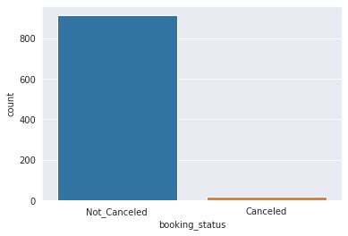

```python
sns.countplot(data=repeat_guests, x='booking_status')
plt.show()
```

```python
repeat_guests['booking_status'].value_counts()
```

```
Not_Canceled    914
Canceled         16
Name: booking_status, dtype: int64
```

Observation: Only 16 of the 930 bookings made by repeat guests were canceled, which is ~1.7%. Seems that repeat customers tend to cancel a lot less than others (since 33% of all bookings are canceled).

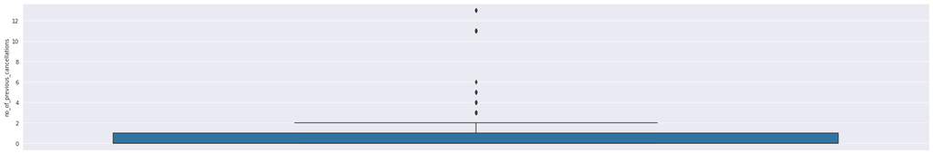

```python
plt.figure(figsize=(30,5))
sns.boxplot(data=repeat_guests, y='no_of_previous_cancellations')
plt.show()
```

```python
repeat_guests['no_of_previous_cancellations'].value_counts()
```

```
0     592
1     198
2      46
3      43
11     25
5      11
4      10
13      4
6       1
Name: no_of_previous_cancellations, dtype: int64
```

Observation: However, when we take a closer look we see another column with number of previous cancellations. There we can see that only 592 of the 930 repeat customers have never cancelled a reservations, which is only 63%.

### 6. Many guests have special requirements when booking a hotel room. Do these requirements affect booking cancellation?

```python
# first let's look at the count of guests at varying levels of special requests
data['no_of_special_requests'].value_counts()
```

```
0    19777
1    11373
2     4364
3      675
4       78
5        8
Name: no_of_special_requests, dtype: int64
```

```python
data['no_of_special_requests'].value_counts(normalize='true')
```

```
0    0.545196
1    0.313522
2    0.120303
3    0.018608
4    0.002150
5    0.000221
Name: no_of_special_requests, dtype: float64
```

Observation: ~54% of bookings had no special requests.

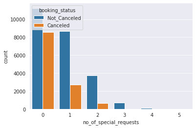

```python
# let's look at the number of bookings with each # of special requests and whether they were canceled or not
sns.countplot(data=data, x='no_of_special_requests', hue='booking_status')
plt.show()
```

```python
# let's look at the count of reservations by # of special requests and booking status
data.groupby('no_of_special_requests')['booking_status'].value_counts()
```

```
no_of_special_requests  booking_status
0                       Not_Canceled      11232
                        Canceled           8545
1                       Not_Canceled       8670
                        Canceled           2703
2                       Not_Canceled       3727
                        Canceled            637
3                       Not_Canceled        675
4                       Not_Canceled         78
5                       Not_Canceled          8
Name: booking_status, dtype: int64
```

```python
data.groupby('no_of_special_requests')['booking_status'].value_counts(normalize='true')
```

```
no_of_special_requests  booking_status
0                       Not_Canceled      0.567932
                        Canceled          0.432068
1                       Not_Canceled      0.762332
                        Canceled          0.237668
2                       Not_Canceled      0.854033
                        Canceled          0.145967
3                       Not_Canceled      1.000000
4                       Not_Canceled      1.000000
5                       Not_Canceled      1.000000
Name: booking_status, dtype: float64
```

Observations:

- The majority of reservations have between 0-2 special requests.
- Reservations with more special requests seem less likely to be cancelled, with those having 3-5 special requests never being cancelled.
- Reservations with no special requests (the majority) have the highest chance of being cancelled. We are seeing a cancellation rate around 43% for those.

## Data Preprocessing

- Missing value treatment (if needed)
- Feature engineering (if needed)
- Outlier detection and treatment (if needed)
- Preparing data for modeling
- Any other preprocessing steps (if needed)

We took care of missing values earlier, and there are no outliers that seem too far fetched, so we will not need to treat those.

### Feature Engineering

- We need to use get dummies on some of our categorical variables: type_of_meal_plan, room_type_reserved, and market_segment_type.
- We need to drop the Booking_ID column.
- And finally we need to change booking_status to 0/1.

```python
# convert type of meal plan
df = pd.get_dummies(data, columns=["type_of_meal_plan"], drop_first=True)
df.head()
```

|  | Booking_ID | no_of_adults | no_of_children | no_of_weekend_nights | no_of_week_nights | required_car_parking_space | room_type_reserved | lead_time | arrival_year | arrival_month | arrival_date | market_segment_type | repeated_guest | no_of_previous_cancellations | no_of_previous_bookings_not_canceled | avg_price_per_room | no_of_special_requests | booking_status | type_of_meal_plan_Meal Plan 2 | type_of_meal_plan_Meal Plan 3 | type_of_meal_plan_Not Selected |
| --- | --- | --- | --- | --- | --- | --- | --- | --- | --- | --- | --- | --- | --- | --- | --- | --- | --- | --- | --- | --- | --- |
| 0 | INN00001 | 2 | 0 | 1 | 2 | 0 | Room_Type 1 | 224 | 2017 | 10 | 2 | Offline | 0 | 0 | 0 | 65.00000 | 0 | Not_Canceled | 0 | 0 | 0 |
| 1 | INN00002 | 2 | 0 | 2 | 3 | 0 | Room_Type 1 | 5 | 2018 | 11 | 6 | Online | 0 | 0 | 0 | 106.68000 | 1 | Not_Canceled | 0 | 0 | 1 |
| 2 | INN00003 | 1 | 0 | 2 | 1 | 0 | Room_Type 1 | 1 | 2018 | 2 | 28 | Online | 0 | 0 | 0 | 60.00000 | 0 | Canceled | 0 | 0 | 0 |
| 3 | INN00004 | 2 | 0 | 0 | 2 | 0 | Room_Type 1 | 211 | 2018 | 5 | 20 | Online | 0 | 0 | 0 | 100.00000 | 0 | Canceled | 0 | 0 | 0 |
| 4 | INN00005 | 2 | 0 | 1 | 1 | 0 | Room_Type 1 | 48 | 2018 | 4 | 11 | Online | 0 | 0 | 0 | 94.50000 | 0 | Canceled | 0 | 0 | 1 |

```python
# convert type of room reserved
df = pd.get_dummies(df, columns=["room_type_reserved"], drop_first=True)
df.head()
```

|  | Booking_ID | no_of_adults | no_of_children | no_of_weekend_nights | no_of_week_nights | required_car_parking_space | lead_time | arrival_year | arrival_month | arrival_date | market_segment_type | repeated_guest | no_of_previous_cancellations | no_of_previous_bookings_not_canceled | avg_price_per_room | no_of_special_requests | booking_status | type_of_meal_plan_Meal Plan 2 | type_of_meal_plan_Meal Plan 3 | type_of_meal_plan_Not Selected | room_type_reserved_Room_Type 2 | room_type_reserved_Room_Type 3 | room_type_reserved_Room_Type 4 | room_type_reserved_Room_Type 5 | room_type_reserved_Room_Type 6 | room_type_reserved_Room_Type 7 |
| --- | --- | --- | --- | --- | --- | --- | --- | --- | --- | --- | --- | --- | --- | --- | --- | --- | --- | --- | --- | --- | --- | --- | --- | --- | --- | --- |
| 0 | INN00001 | 2 | 0 | 1 | 2 | 0 | 224 | 2017 | 10 | 2 | Offline | 0 | 0 | 0 | 65.00000 | 0 | Not_Canceled | 0 | 0 | 0 | 0 | 0 | 0 | 0 | 0 | 0 |
| 1 | INN00002 | 2 | 0 | 2 | 3 | 0 | 5 | 2018 | 11 | 6 | Online | 0 | 0 | 0 | 106.68000 | 1 | Not_Canceled | 0 | 0 | 1 | 0 | 0 | 0 | 0 | 0 | 0 |
| 2 | INN00003 | 1 | 0 | 2 | 1 | 0 | 1 | 2018 | 2 | 28 | Online | 0 | 0 | 0 | 60.00000 | 0 | Canceled | 0 | 0 | 0 | 0 | 0 | 0 | 0 | 0 | 0 |
| 3 | INN00004 | 2 | 0 | 0 | 2 | 0 | 211 | 2018 | 5 | 20 | Online | 0 | 0 | 0 | 100.00000 | 0 | Canceled | 0 | 0 | 0 | 0 | 0 | 0 | 0 | 0 | 0 |
| 4 | INN00005 | 2 | 0 | 1 | 1 | 0 | 48 | 2018 | 4 | 11 | Online | 0 | 0 | 0 | 94.50000 | 0 | Canceled | 0 | 0 | 1 | 0 | 0 | 0 | 0 | 0 | 0 |

```python
# convert market segment type
df = pd.get_dummies(df, columns=["market_segment_type"], drop_first=True)
df.head()
```

|  | Booking_ID | no_of_adults | no_of_children | no_of_weekend_nights | no_of_week_nights | required_car_parking_space | lead_time | arrival_year | arrival_month | arrival_date | repeated_guest | no_of_previous_cancellations | no_of_previous_bookings_not_canceled | avg_price_per_room | no_of_special_requests | booking_status | type_of_meal_plan_Meal Plan 2 | type_of_meal_plan_Meal Plan 3 | type_of_meal_plan_Not Selected | room_type_reserved_Room_Type 2 | room_type_reserved_Room_Type 3 | room_type_reserved_Room_Type 4 | room_type_reserved_Room_Type 5 | room_type_reserved_Room_Type 6 | room_type_reserved_Room_Type 7 | market_segment_type_Complementary | market_segment_type_Corporate | market_segment_type_Offline | market_segment_type_Online |
| --- | --- | --- | --- | --- | --- | --- | --- | --- | --- | --- | --- | --- | --- | --- | --- | --- | --- | --- | --- | --- | --- | --- | --- | --- | --- | --- | --- | --- | --- |
| 0 | INN00001 | 2 | 0 | 1 | 2 | 0 | 224 | 2017 | 10 | 2 | 0 | 0 | 0 | 65.00000 | 0 | Not_Canceled | 0 | 0 | 0 | 0 | 0 | 0 | 0 | 0 | 0 | 0 | 0 | 1 | 0 |
| 1 | INN00002 | 2 | 0 | 2 | 3 | 0 | 5 | 2018 | 11 | 6 | 0 | 0 | 0 | 106.68000 | 1 | Not_Canceled | 0 | 0 | 1 | 0 | 0 | 0 | 0 | 0 | 0 | 0 | 0 | 0 | 1 |
| 2 | INN00003 | 1 | 0 | 2 | 1 | 0 | 1 | 2018 | 2 | 28 | 0 | 0 | 0 | 60.00000 | 0 | Canceled | 0 | 0 | 0 | 0 | 0 | 0 | 0 | 0 | 0 | 0 | 0 | 0 | 1 |
| 3 | INN00004 | 2 | 0 | 0 | 2 | 0 | 211 | 2018 | 5 | 20 | 0 | 0 | 0 | 100.00000 | 0 | Canceled | 0 | 0 | 0 | 0 | 0 | 0 | 0 | 0 | 0 | 0 | 0 | 0 | 1 |
| 4 | INN00005 | 2 | 0 | 1 | 1 | 0 | 48 | 2018 | 4 | 11 | 0 | 0 | 0 | 94.50000 | 0 | Canceled | 0 | 0 | 1 | 0 | 0 | 0 | 0 | 0 | 0 | 0 | 0 | 0 | 1 |

```python
# drop the Booking_ID column
df.drop('Booking_ID', axis=1, inplace=True)
df.head()
```

|  | no_of_adults | no_of_children | no_of_weekend_nights | no_of_week_nights | required_car_parking_space | lead_time | arrival_year | arrival_month | arrival_date | repeated_guest | no_of_previous_cancellations | no_of_previous_bookings_not_canceled | avg_price_per_room | no_of_special_requests | booking_status | type_of_meal_plan_Meal Plan 2 | type_of_meal_plan_Meal Plan 3 | type_of_meal_plan_Not Selected | room_type_reserved_Room_Type 2 | room_type_reserved_Room_Type 3 | room_type_reserved_Room_Type 4 | room_type_reserved_Room_Type 5 | room_type_reserved_Room_Type 6 | room_type_reserved_Room_Type 7 | market_segment_type_Complementary | market_segment_type_Corporate | market_segment_type_Offline | market_segment_type_Online |
| --- | --- | --- | --- | --- | --- | --- | --- | --- | --- | --- | --- | --- | --- | --- | --- | --- | --- | --- | --- | --- | --- | --- | --- | --- | --- | --- | --- | --- |
| 0 | 2 | 0 | 1 | 2 | 0 | 224 | 2017 | 10 | 2 | 0 | 0 | 0 | 65.00000 | 0 | Not_Canceled | 0 | 0 | 0 | 0 | 0 | 0 | 0 | 0 | 0 | 0 | 0 | 1 | 0 |
| 1 | 2 | 0 | 2 | 3 | 0 | 5 | 2018 | 11 | 6 | 0 | 0 | 0 | 106.68000 | 1 | Not_Canceled | 0 | 0 | 1 | 0 | 0 | 0 | 0 | 0 | 0 | 0 | 0 | 0 | 1 |
| 2 | 1 | 0 | 2 | 1 | 0 | 1 | 2018 | 2 | 28 | 0 | 0 | 0 | 60.00000 | 0 | Canceled | 0 | 0 | 0 | 0 | 0 | 0 | 0 | 0 | 0 | 0 | 0 | 0 | 1 |
| 3 | 2 | 0 | 0 | 2 | 0 | 211 | 2018 | 5 | 20 | 0 | 0 | 0 | 100.00000 | 0 | Canceled | 0 | 0 | 0 | 0 | 0 | 0 | 0 | 0 | 0 | 0 | 0 | 0 | 1 |
| 4 | 2 | 0 | 1 | 1 | 0 | 48 | 2018 | 4 | 11 | 0 | 0 | 0 | 94.50000 | 0 | Canceled | 0 | 0 | 1 | 0 | 0 | 0 | 0 | 0 | 0 | 0 | 0 | 0 | 1 |

```python
# change the booking_status to 1/0
df.replace({'Canceled': 1, 'Not_Canceled': 0}, inplace=True)
df.head()
```

|  | no_of_adults | no_of_children | no_of_weekend_nights | no_of_week_nights | required_car_parking_space | lead_time | arrival_year | arrival_month | arrival_date | repeated_guest | no_of_previous_cancellations | no_of_previous_bookings_not_canceled | avg_price_per_room | no_of_special_requests | booking_status | type_of_meal_plan_Meal Plan 2 | type_of_meal_plan_Meal Plan 3 | type_of_meal_plan_Not Selected | room_type_reserved_Room_Type 2 | room_type_reserved_Room_Type 3 | room_type_reserved_Room_Type 4 | room_type_reserved_Room_Type 5 | room_type_reserved_Room_Type 6 | room_type_reserved_Room_Type 7 | market_segment_type_Complementary | market_segment_type_Corporate | market_segment_type_Offline | market_segment_type_Online |
| --- | --- | --- | --- | --- | --- | --- | --- | --- | --- | --- | --- | --- | --- | --- | --- | --- | --- | --- | --- | --- | --- | --- | --- | --- | --- | --- | --- | --- |
| 0 | 2 | 0 | 1 | 2 | 0 | 224 | 2017 | 10 | 2 | 0 | 0 | 0 | 65.00000 | 0 | 0 | 0 | 0 | 0 | 0 | 0 | 0 | 0 | 0 | 0 | 0 | 0 | 1 | 0 |
| 1 | 2 | 0 | 2 | 3 | 0 | 5 | 2018 | 11 | 6 | 0 | 0 | 0 | 106.68000 | 1 | 0 | 0 | 0 | 1 | 0 | 0 | 0 | 0 | 0 | 0 | 0 | 0 | 0 | 1 |
| 2 | 1 | 0 | 2 | 1 | 0 | 1 | 2018 | 2 | 28 | 0 | 0 | 0 | 60.00000 | 0 | 1 | 0 | 0 | 0 | 0 | 0 | 0 | 0 | 0 | 0 | 0 | 0 | 0 | 1 |
| 3 | 2 | 0 | 0 | 2 | 0 | 211 | 2018 | 5 | 20 | 0 | 0 | 0 | 100.00000 | 0 | 1 | 0 | 0 | 0 | 0 | 0 | 0 | 0 | 0 | 0 | 0 | 0 | 0 | 1 |
| 4 | 2 | 0 | 1 | 1 | 0 | 48 | 2018 | 4 | 11 | 0 | 0 | 0 | 94.50000 | 0 | 1 | 0 | 0 | 1 | 0 | 0 | 0 | 0 | 0 | 0 | 0 | 0 | 0 | 1 |

```python
# check that booking status is now 0/1
df['booking_status'].unique()
```

```
array([0, 1])
```

### Split the data into Train & Test

```python
# independent variable
X = df.drop(["booking_status"], axis=1)
# dependent variable
Y = df["booking_status"]

# adding a contstant to X variable
X = add_constant(X)

# Splitting data in train and test sets with 70/30
X_train, X_test, y_train, y_test = train_test_split(
    X, Y, test_size=0.30, random_state=1, stratify=Y
)
```

## EDA

- It is a good idea to explore the data once again after manipulating it.

```python
# let's check to make sure we have no more nulls, our new columns were added, our Booking ID column was dropped, and that our data types are all numeric.
df.info()
```

```
<class 'pandas.core.frame.DataFrame'>
RangeIndex: 36275 entries, 0 to 36274
Data columns (total 28 columns):
 #   Column                                Non-Null Count  Dtype
---  ------                                --------------  -----
 0   no_of_adults                          36275 non-null  int64
 1   no_of_children                        36275 non-null  int64
 2   no_of_weekend_nights                  36275 non-null  int64
 3   no_of_week_nights                     36275 non-null  int64
 4   required_car_parking_space            36275 non-null  int64
 5   lead_time                             36275 non-null  int64
 6   arrival_year                          36275 non-null  int64
 7   arrival_month                         36275 non-null  int64
 8   arrival_date                          36275 non-null  int64
 9   repeated_guest                        36275 non-null  int64
```

[output cut: 20 more lines]

```python
df.describe(include='all').T
```

|  | count | mean | std | min | 25% | 50% | 75% | max |
| --- | --- | --- | --- | --- | --- | --- | --- | --- |
| no_of_adults | 36275.00000 | 1.84496 | 0.51871 | 0.00000 | 2.00000 | 2.00000 | 2.00000 | 4.00000 |
| no_of_children | 36275.00000 | 0.10528 | 0.40265 | 0.00000 | 0.00000 | 0.00000 | 0.00000 | 10.00000 |
| no_of_weekend_nights | 36275.00000 | 0.81072 | 0.87064 | 0.00000 | 0.00000 | 1.00000 | 2.00000 | 7.00000 |
| no_of_week_nights | 36275.00000 | 2.20430 | 1.41090 | 0.00000 | 1.00000 | 2.00000 | 3.00000 | 17.00000 |
| required_car_parking_space | 36275.00000 | 0.03099 | 0.17328 | 0.00000 | 0.00000 | 0.00000 | 0.00000 | 1.00000 |
| lead_time | 36275.00000 | 85.23256 | 85.93082 | 0.00000 | 17.00000 | 57.00000 | 126.00000 | 443.00000 |
| arrival_year | 36275.00000 | 2017.82043 | 0.38384 | 2017.00000 | 2018.00000 | 2018.00000 | 2018.00000 | 2018.00000 |
| arrival_month | 36275.00000 | 7.42365 | 3.06989 | 1.00000 | 5.00000 | 8.00000 | 10.00000 | 12.00000 |
| arrival_date | 36275.00000 | 15.59700 | 8.74045 | 1.00000 | 8.00000 | 16.00000 | 23.00000 | 31.00000 |
| repeated_guest | 36275.00000 | 0.02564 | 0.15805 | 0.00000 | 0.00000 | 0.00000 | 0.00000 | 1.00000 |
| no_of_previous_cancellations | 36275.00000 | 0.02335 | 0.36833 | 0.00000 | 0.00000 | 0.00000 | 0.00000 | 13.00000 |
| no_of_previous_bookings_not_canceled | 36275.00000 | 0.15341 | 1.75417 | 0.00000 | 0.00000 | 0.00000 | 0.00000 | 58.00000 |
| avg_price_per_room | 36275.00000 | 104.92595 | 32.68758 | 0.50000 | 81.00000 | 100.00000 | 120.00000 | 540.00000 |
| no_of_special_requests | 36275.00000 | 0.61966 | 0.78624 | 0.00000 | 0.00000 | 0.00000 | 1.00000 | 5.00000 |
| booking_status | 36275.00000 | 0.32764 | 0.46936 | 0.00000 | 0.00000 | 0.00000 | 1.00000 | 1.00000 |
| type_of_meal_plan_Meal Plan 2 | 36275.00000 | 0.09111 | 0.28777 | 0.00000 | 0.00000 | 0.00000 | 0.00000 | 1.00000 |
| type_of_meal_plan_Meal Plan 3 | 36275.00000 | 0.00014 | 0.01174 | 0.00000 | 0.00000 | 0.00000 | 0.00000 | 1.00000 |
| type_of_meal_plan_Not Selected | 36275.00000 | 0.14142 | 0.34846 | 0.00000 | 0.00000 | 0.00000 | 0.00000 | 1.00000 |
| room_type_reserved_Room_Type 2 | 36275.00000 | 0.01908 | 0.13680 | 0.00000 | 0.00000 | 0.00000 | 0.00000 | 1.00000 |
| room_type_reserved_Room_Type 3 | 36275.00000 | 0.00019 | 0.01389 | 0.00000 | 0.00000 | 0.00000 | 0.00000 | 1.00000 |
| room_type_reserved_Room_Type 4 | 36275.00000 | 0.16697 | 0.37296 | 0.00000 | 0.00000 | 0.00000 | 0.00000 | 1.00000 |
| room_type_reserved_Room_Type 5 | 36275.00000 | 0.00731 | 0.08516 | 0.00000 | 0.00000 | 0.00000 | 0.00000 | 1.00000 |
| room_type_reserved_Room_Type 6 | 36275.00000 | 0.02663 | 0.16100 | 0.00000 | 0.00000 | 0.00000 | 0.00000 | 1.00000 |
| room_type_reserved_Room_Type 7 | 36275.00000 | 0.00436 | 0.06585 | 0.00000 | 0.00000 | 0.00000 | 0.00000 | 1.00000 |
| market_segment_type_Complementary | 36275.00000 | 0.01078 | 0.10326 | 0.00000 | 0.00000 | 0.00000 | 0.00000 | 1.00000 |
| market_segment_type_Corporate | 36275.00000 | 0.05560 | 0.22916 | 0.00000 | 0.00000 | 0.00000 | 0.00000 | 1.00000 |
| market_segment_type_Offline | 36275.00000 | 0.29023 | 0.45387 | 0.00000 | 0.00000 | 0.00000 | 1.00000 | 1.00000 |
| market_segment_type_Online | 36275.00000 | 0.63994 | 0.48002 | 0.00000 | 0.00000 | 1.00000 | 1.00000 | 1.00000 |

Observation: Our features look good! We are ready to move on.

```python
# check test dataset
X_test.head()
```

|  | const | no_of_adults | no_of_children | no_of_weekend_nights | no_of_week_nights | required_car_parking_space | lead_time | arrival_year | arrival_month | arrival_date | repeated_guest | no_of_previous_cancellations | no_of_previous_bookings_not_canceled | avg_price_per_room | no_of_special_requests | type_of_meal_plan_Meal Plan 2 | type_of_meal_plan_Meal Plan 3 | type_of_meal_plan_Not Selected | room_type_reserved_Room_Type 2 | room_type_reserved_Room_Type 3 | room_type_reserved_Room_Type 4 | room_type_reserved_Room_Type 5 | room_type_reserved_Room_Type 6 | room_type_reserved_Room_Type 7 | market_segment_type_Complementary | market_segment_type_Corporate | market_segment_type_Offline | market_segment_type_Online |
| --- | --- | --- | --- | --- | --- | --- | --- | --- | --- | --- | --- | --- | --- | --- | --- | --- | --- | --- | --- | --- | --- | --- | --- | --- | --- | --- | --- | --- |
| 22801 | 1.00000 | 2 | 0 | 0 | 1 | 0 | 0 | 2018 | 8 | 25 | 0 | 0 | 0 | 92.98000 | 0 | 0 | 0 | 1 | 0 | 0 | 0 | 0 | 0 | 0 | 0 | 0 | 0 | 1 |
| 3830 | 1.00000 | 2 | 0 | 0 | 3 | 0 | 80 | 2018 | 11 | 10 | 0 | 0 | 0 | 120.90000 | 2 | 0 | 0 | 0 | 0 | 0 | 0 | 0 | 0 | 0 | 0 | 0 | 0 | 1 |
| 33959 | 1.00000 | 2 | 0 | 1 | 3 | 0 | 23 | 2017 | 9 | 14 | 0 | 0 | 0 | 105.00000 | 2 | 0 | 0 | 0 | 0 | 0 | 0 | 0 | 0 | 0 | 0 | 0 | 0 | 1 |
| 14068 | 1.00000 | 3 | 0 | 0 | 2 | 0 | 21 | 2018 | 6 | 1 | 0 | 0 | 0 | 157.00000 | 0 | 0 | 0 | 0 | 0 | 0 | 1 | 0 | 0 | 0 | 0 | 0 | 0 | 1 |
| 10215 | 1.00000 | 3 | 0 | 2 | 1 | 0 | 13 | 2018 | 2 | 6 | 0 | 0 | 0 | 130.00000 | 2 | 0 | 0 | 0 | 0 | 0 | 0 | 0 | 0 | 0 | 0 | 0 | 0 | 1 |

## Building a Logistic Regression model

```python
# fitting the model on training set
logit = sm.Logit(y_train, X_train.astype(float))
lg = logit.fit()
```

```
Optimization terminated successfully.
         Current function value: 0.423907
         Iterations 26
```

```python
# let's print the logistic regression summary
print(lg.summary())
```

```
                           Logit Regression Results
==============================================================================
Dep. Variable:         booking_status   No. Observations:                25392
Model:                          Logit   Df Residuals:                    25364
Method:                           MLE   Df Model:                           27
Date:                Fri, 27 Jan 2023   Pseudo R-squ.:                  0.3298
Time:                        22:44:35   Log-Likelihood:                -10764.
converged:                       True   LL-Null:                       -16060.
Covariance Type:            nonrobust   LLR p-value:                     0.000
========================================================================================================
                                           coef    std err          z      P>|z|      [0.025      0.975]
--------------------------------------------------------------------------------------------------------
const                                 -952.7967    121.180     -7.863      0.000   -1190.306    -715.288
no_of_adults                             0.0540      0.038      1.438      0.151      -0.020       0.128
no_of_children                           0.0974      0.060      1.612      0.107      -0.021       0.216
no_of_weekend_nights                     0.1483      0.020      7.484      0.000       0.109       0.187
no_of_week_nights                        0.0375      0.012      3.062      0.002       0.014       0.062
required_car_parking_space              -1.5987      0.137    -11.662      0.000      -1.867      -1.330
lead_time                                0.0157      0.000     58.816      0.000       0.015       0.016
arrival_year                             0.4708      0.060      7.841      0.000       0.353       0.589
arrival_month                           -0.0465      0.006     -7.176      0.000      -0.059      -0.034
arrival_date                             0.0030      0.002      1.545      0.122      -0.001       0.007
repeated_guest                          -1.9353      0.758     -2.554      0.011      -3.420      -0.450
no_of_previous_cancellations             0.3472      0.102      3.413      0.001       0.148       0.547
no_of_previous_bookings_not_canceled    -1.3734      0.903     -1.522      0.128      -3.143       0.396
avg_price_per_room                       0.0179      0.001     23.646      0.000       0.016       0.019
no_of_special_requests                  -1.4826      0.030    -48.830      0.000      -1.542      -1.423
type_of_meal_plan_Meal Plan 2            0.1633      0.067      2.444      0.015       0.032       0.294
type_of_meal_plan_Meal Plan 3           32.9813    9.4e+06   3.51e-06      1.000   -1.84e+07    1.84e+07
type_of_meal_plan_Not Selected           0.2014      0.053      3.780      0.000       0.097       0.306
room_type_reserved_Room_Type 2          -0.4189      0.133     -3.154      0.002      -0.679      -0.159
room_type_reserved_Room_Type 3           1.2013      1.891      0.635      0.525      -2.506       4.908
room_type_reserved_Room_Type 4          -0.2532      0.053     -4.748      0.000      -0.358      -0.149
room_type_reserved_Room_Type 5          -0.6675      0.214     -3.113      0.002      -1.088      -0.247
room_type_reserved_Room_Type 6          -0.8164      0.153     -5.346      0.000      -1.116      -0.517
room_type_reserved_Room_Type 7          -1.3274      0.298     -4.460      0.000      -1.911      -0.744
market_segment_type_Complementary      -92.8557   6.89e+13  -1.35e-12      1.000   -1.35e+14    1.35e+14
market_segment_type_Corporate           -0.8403      0.276     -3.045      0.002      -1.381      -0.300
market_segment_type_Offline             -1.7529      0.264     -6.642      0.000      -2.270      -1.236
market_segment_type_Online              -0.0096      0.261     -0.037      0.971      -0.521       0.502
========================================================================================================
```

## Initial Model performance evaluation

```python
# predicting on training set
# default threshold is 0.5, if predicted probability is greater than 0.5 the observation will be classified as 1

pred_train = lg.predict(X_train) > 0.5
pred_train = np.round(pred_train)
```

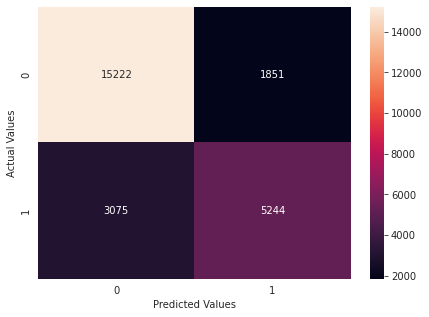

```python
# let's look at the confusion matrix for the training dataset
cm = confusion_matrix(y_train, pred_train)
plt.figure(figsize=(7, 5))
sns.heatmap(cm, annot=True, fmt="g")
plt.xlabel("Predicted Values")
plt.ylabel("Actual Values")
plt.show()
```

Observations:

- True Positives (TP): A booking was cancelled and the model predicted it was going to be cancelled.
- True Negatives (TN): A booking was not cancelled and the model predicted it would not be cancelled.
- False Positives (FP): The model predicted the booking was going to be cancelled and it wasn't.
- False Negatives (FN): The model predicted the booking was not going to be cancelled and it was.

```python
# let's check model accuracy
print("Accuracy on training set : ", accuracy_score(y_train, pred_train))
```

```
Accuracy on training set :  0.8060018903591682
```

Observation: The model seems to be performing well on the training set.